# RegresionLogistica_FugaClientes

Laura Piñeros

Febrero_2022

## Aplicación del modelo

En primer lugar se fija el directorio de trabajo donde tenemos las funciones y los datos.

```
## [1] "C:/Users/Laura/Documents/GitHub/Modelizacion_in_R/RegresionLog_FugaClientes"
```

Procedemos a la lectura de los datos depurados.

```r
# Parto de los datos sin atípicos ni ausentes guardados
datos<-readRDS("C:/Users/Laura/Dropbox/UCM/Mineria_y_modelizacion_1/Tarea/datosFugaClientes.RDS")
#names(datos)
varObjBin<-datos$varObjBin
input<-datos[,-(1)]
```

Variables control:

```r
# Creo la variable aleatoria
input$aleatorio<-runif(nrow(input))
input$aleatorio2<-runif(nrow(input))
str(input)
```

```
## 'data.frame':    6353 obs. of  23 variables:
##  $ ID             : num  4858 3587 2338 4997 5879 ...
##  $ Genero         : Factor w/ 2 levels "Female","Male": 1 2 2 2 1 1 2 1 2 2 ...
##  $ Mayor65        : Factor w/ 2 levels "0","1": 1 1 1 1 1 1 1 1 1 1 ...
##  $ Conyuge        : Factor w/ 2 levels "No","Yes": 2 1 1 1 1 1 1 1 2 1 ...
##  $ PersCargo      : Factor w/ 2 levels "No","Yes": 1 1 1 1 1 1 2 1 1 2 ...
##  $ Antiguedad     : num  1 34 2 45 38.8 ...
##  $ Telf_serv      : Factor w/ 2 levels "No","Yes": 1 2 2 1 2 2 2 1 2 2 ...
##  $ VariasLineas   : Factor w/ 2 levels "No","Yes": 1 1 1 1 1 2 2 1 2 1 ...
##  $ Int_serv       : Factor w/ 3 levels "DSL","Fiber optic",..: 1 1 1 1 2 2 2 2 2 1 ...
##  $ Seguridad      : Factor w/ 2 levels "No","Yes": 1 2 2 2 1 1 1 2 1 2 ...
##  $ CopiaSeguridad : Factor w/ 2 levels "No","Yes": 2 1 2 1 1 1 2 1 1 2 ...
##  $ Antivirus_disp : Factor w/ 2 levels "No","Yes": 1 2 1 2 1 2 1 1 2 1 ...
##  $ Soporte_tecnico: Factor w/ 2 levels "No","Yes": 1 1 1 2 1 1 1 1 2 1 ...
##  $ TV_streaming   : Factor w/ 2 levels "No","Yes": 1 1 1 1 1 2 2 1 2 1 ...
##  $ Peliculas      : Factor w/ 2 levels "No","Yes": 1 1 1 1 1 2 1 1 2 1 ...
##  $ Contrato       : Factor w/ 3 levels "Month-to-month",..: 1 2 1 2 1 1 1 1 1 1 ...
##  $ Fact_sinPapel  : Factor w/ 2 levels "No","Yes": 2 1 2 1 2 2 2 1 2 1 ...
##  $ MetodoPago     : Factor w/ 4 levels "Bank transfer (automatic)",..: 2 4 4 4 3 4 2 4 3 3 ...
##  $ FacturaMes     : num  74.6 32.5 53.9 42.3 70.7 ...
##  $ FacturaTotal   : num  29.9 1889.5 108.2 1840.8 151.7 ...
##  $ prop_missings  : num  0.1 0.05 0 0.1 0.05 0.05 0.05 0.05 0.05 0.1 ...
##  $ aleatorio      : num  0.677 0.749 0.502 0.64 0.361 ...
##  $ aleatorio2     : num  0.252 0.71 0.017 0.291 0.855 ...
```

## Estudio descriptivo de relaciones con la respuesta

En este apartado intentaremos descubrir a priori las relaciones marginales de las variables con la variable objetivo binaria para hacernos una idea de cuales de ellas serán potencialmente influyentes en los modelos de regresión logística que ajustemos.

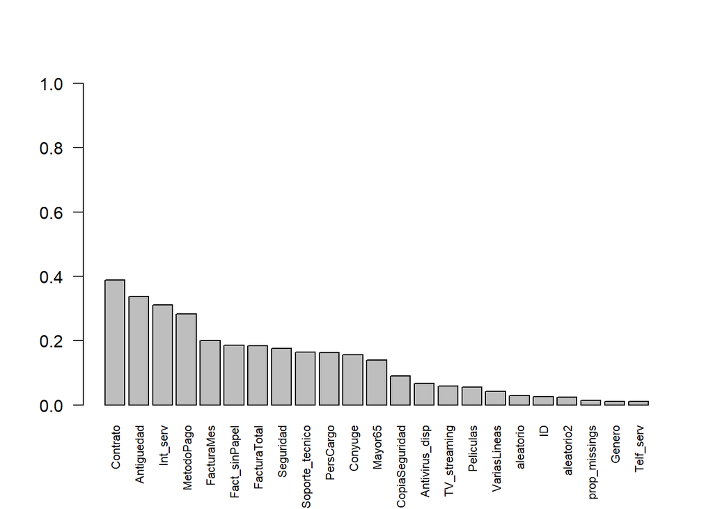

```r
#Obtengo la importancia de las variables.
#Falla si hay alguna variable cuantitativa con menos de 6 valores diferentes
input$prop_missings <-as.factor(input$prop_missings)
graficoVcramer(input,varObjBin)
```

Podemos decir que las variables tentativas para el modelado son:

- Contrato
- Antiguedad
- Int_serv
- MetodoPago

Después de aleatorio2 empezamos a sospechar que las relaciones con la variable objetivo si pueden ser casualidad.

Veamos gráficamente la relacion entre las varaibles con la objetivo, por medio del mosaico. Tomemos una variable que ifluye y tomemos otra que no tanto a ver que nos resulta.

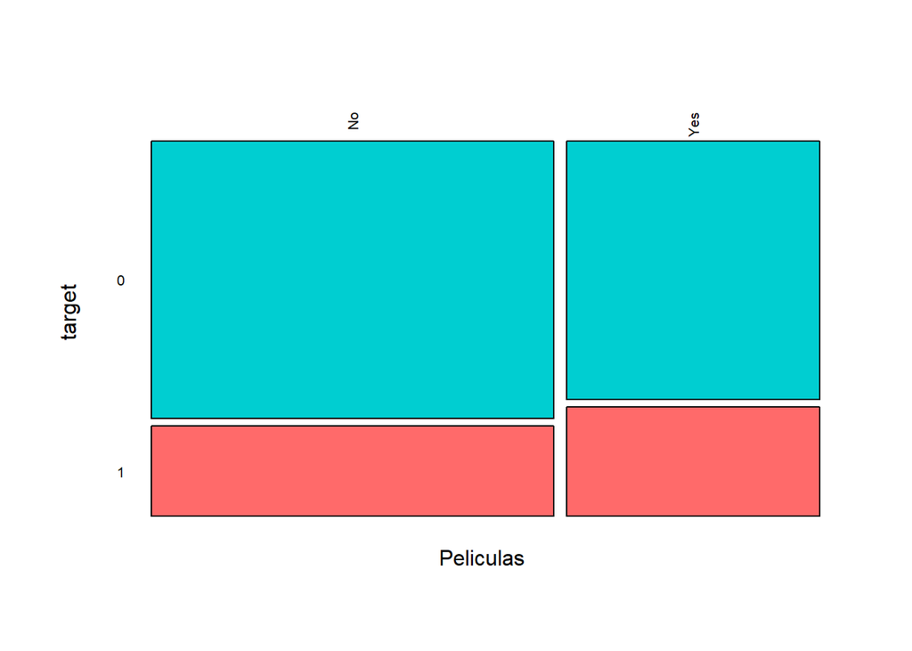

```r
#Veo gráficamente el efecto de dos variables cualitativas sobre la binaria
m1<-mosaico_targetbinaria(input$Peliculas,varObjBin,"Peliculas") #esta no influye
```

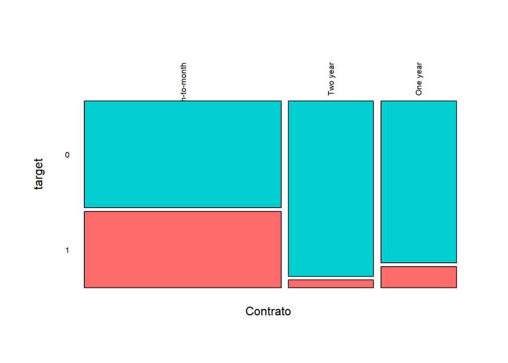

```r
m2<-mosaico_targetbinaria(input$Contrato,varObjBin,"Contrato") #esta sí influye
```

Veamos que efecto tienen dos variables cuantitativas sobre la objetivo binaria.

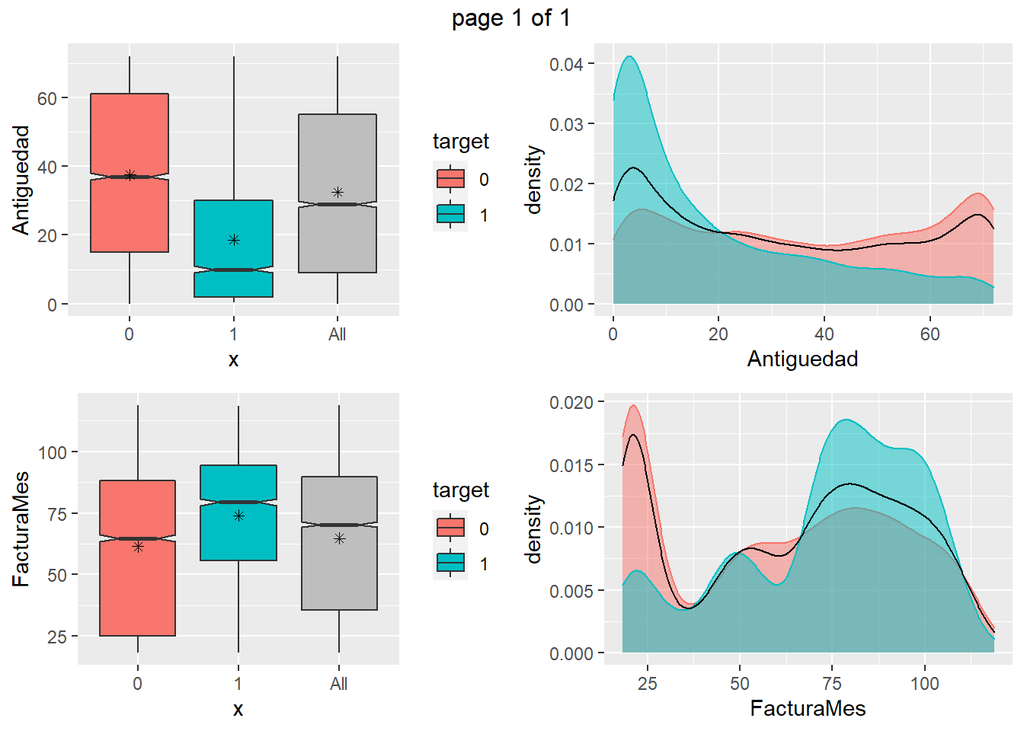

```r
#Veo gráficamente el efecto de dos variables cuantitativas sobre la binaria
bx1<-boxplot_targetbinaria(input$Antiguedad,varObjBin,"Antiguedad")
bx2<-boxplot_targetbinaria(input$FacturaMes,varObjBin,"FacturaMes")
bx4<-boxplot_targetbinaria(input$FacturaTotal,varObjBin,"FacturaTotal")


h1<-hist_targetbinaria(input$Antiguedad,varObjBin,"Antiguedad")
h2<-hist_targetbinaria(input$FacturaMes,varObjBin,"FacturaMes")
h4<-hist_targetbinaria(input$FacturaTotal,varObjBin,"FacturaTotal")

marrangeGrob(list(bx1,bx2,h1,h2),nrow = 2,ncol = 2)
```

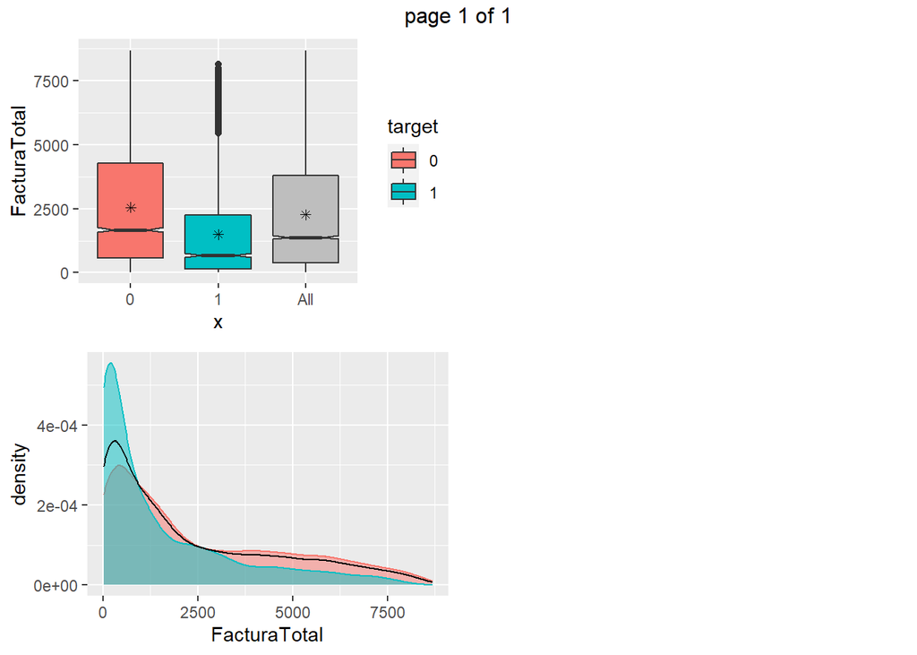

```r
marrangeGrob(list(bx4,h4),nrow = 2,ncol = 2)
```

## Tranformaciones de variables

Vamos a generar las transformaciones de las variable continuas que maximizan la relación con la variable objetivo binaria en sentido de V de Cramer.

```r
#Busco las mejores transformaciones para las variables numéricas con respesto a la variable binaria
input_bin<-cbind(input,Transf_Auto(Filter(is.numeric, input),varObjBin))

# Guardamos el dataset con las tranformaciones
todo_bin<-data.frame(input_bin,varObjBin)
saveRDS(todo_bin,"todo_bin_Fuga_Clientes.RDS")
```

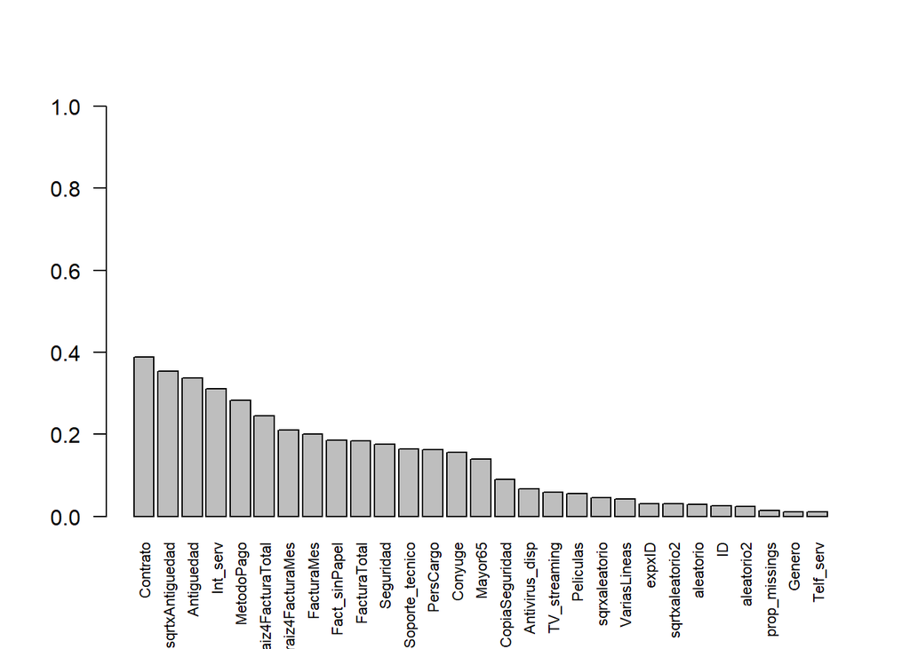

```r
#Obtengo la importancia de las variables.
graficoVcramer(input_bin,varObjBin)
```

Tiene buena pinta, pues no hubo muchos cambios. Hasta acá, quisimos dar una breve descripción a los datos para encontar incidencias con la variable objetivo.

##Modelo de regresión logistica para la predicción de la variable Fuga

```r
#todo<-readRDS("todo_bin")
todo<-todo_bin

freq(todo$varObjBin) #ese ha de ser el error de referencia
```

|  | n | % | val% |
| --- | --- | --- | --- |
| 0 | 4667 | 73.5 | 73.5 |
| 1 | 1686 | 26.5 | 26.5 |

Siguiendo las especificaciones del modelo, este tendrá mas dificultad en reconocer a los 1, es decir, los clientes en fuga.

### Partición training-test

```r
#Hago la partición
set.seed(123456)
trainIndex <- createDataPartition(todo$varObjBin, p=0.8, list=FALSE)
data_train <- todo[trainIndex,c(1:23,30)]
data_test <- todo[-trainIndex,c(1:23,30)]
#data_test <- readRDS("C:/Users/Laura/Desktop/UCM/Documentacion2/Tarea/FugaClientes_test.RDS")
```

Quitemos los efectos no deseados o doblajes de las variables.

```r
# Este fue el modelo manual ganador
modeloManual<-glm(varObjBin~Contrato+Int_serv+Antiguedad,
             data=data_train,family=binomial)
summary(modeloManual)
```

```
##
## Call:
## glm(formula = varObjBin ~ Contrato + Int_serv + Antiguedad, family = binomial,
##     data = data_train)
##
## Deviance Residuals:
##     Min       1Q   Median       3Q      Max
## -1.5609  -0.7227  -0.3320   0.8374   3.0953
##
## Coefficients:
##                      Estimate Std. Error z value Pr(>|z|)
## (Intercept)         -0.285833   0.074170  -3.854 0.000116 ***
## ContratoOne year    -0.934753   0.116092  -8.052 8.16e-16 ***
## ContratoTwo year    -1.519162   0.165049  -9.204  < 2e-16 ***
## Int_servFiber optic  1.185144   0.084730  13.987  < 2e-16 ***
## Int_servNo          -0.839774   0.128909  -6.514 7.29e-11 ***
## Antiguedad          -0.031728   0.002123 -14.943  < 2e-16 ***
## ---
## Signif. codes:  0 '***' 0.001 '**' 0.01 '*' 0.05 '.' 0.1 ' ' 1
##
## (Dispersion parameter for binomial family taken to be 1)
##
##     Null deviance: 5882.3  on 5082  degrees of freedom
## Residual deviance: 4450.7  on 5077  degrees of freedom
## AIC: 4462.7
##
## Number of Fisher Scoring iterations: 6
```

```r
pseudoR2(modeloManual,data_train,"varObjBin")
```

```
## [1] 0.2433689
```

```r
pseudoR2(modeloManual,data_test,"varObjBin")
```

```
## [1] 0.2227703
```

# Esquema de selección de variables por Lasso

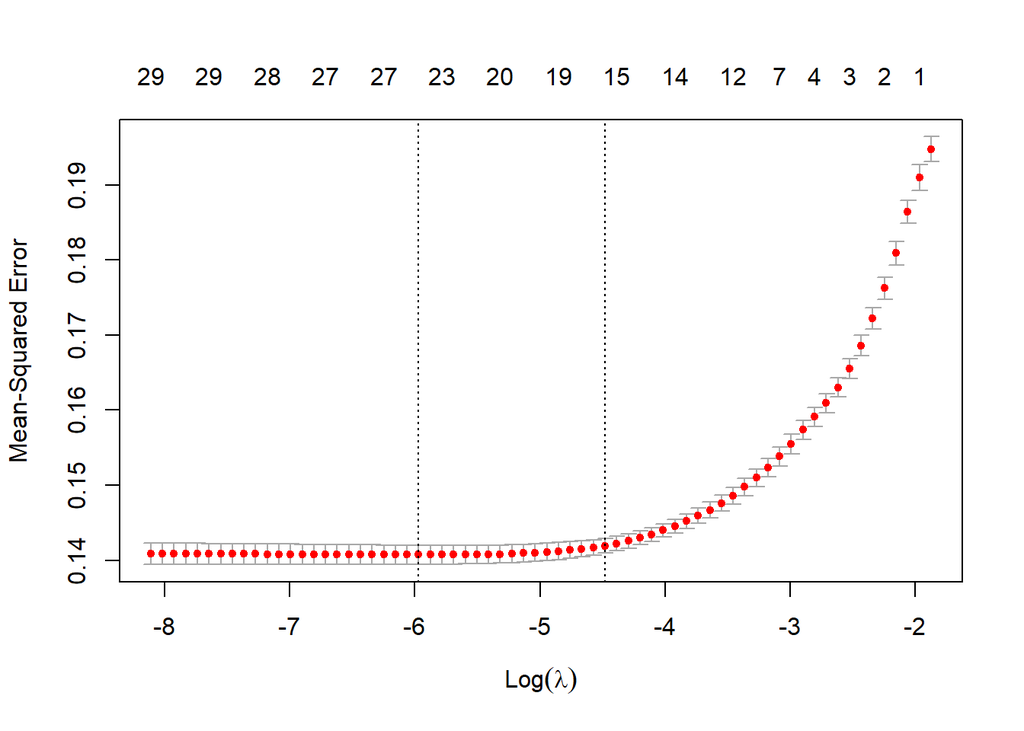

```r
## LASSO, lo hacemos sin interacciones pues, de lo contrario, puede coger interacciones y no las variables que las forman
y <- as.double(as.matrix(data_train[, 24]))
x<-model.matrix(varObjBin~., data=data_train)[,-1]#no cambiar el -1
set.seed(1712)
cv.lasso <- cv.glmnet(x,y,nfolds=5)
plot(cv.lasso)
```

Este es el comportamiento de lambda y el intervalo de 1se. Mostramos lo coeficiente.

```r
(betas<-coef(cv.lasso, s=cv.lasso$lambda.1se))
```

```
## 30 x 1 sparse Matrix of class "dgCMatrix"
##                                              s1
## (Intercept)                        3.511002e-01
## ID                                 .
## GeneroMale                         .
## Mayor651                           4.009340e-02
## ConyugeYes                         .
## PersCargoYes                      -2.067084e-02
## Antiguedad                        -2.600286e-03
## Telf_servYes                      -3.709289e-03
## VariasLineasYes                    2.793244e-02
## Int_servFiber optic                1.612909e-01
## Int_servNo                        -1.075162e-01
## SeguridadYes                      -4.443798e-02
## CopiaSeguridadYes                  .
## Antivirus_dispYes                  .
## Soporte_tecnicoYes                -3.555300e-02
## TV_streamingYes                    3.667794e-02
## PeliculasYes                       1.728011e-02
## ContratoOne year                  -9.573664e-02
## ContratoTwo year                  -6.921778e-02
## Fact_sinPapelYes                   4.522357e-02
## MetodoPagoCredit card (automatic)  .
## MetodoPagoElectronic check         6.485020e-02
## MetodoPagoMailed check             .
## FacturaMes                         1.000097e-05
## FacturaTotal                      -2.971948e-05
## prop_missings0.05                  .
## prop_missings0.1                   .
## prop_missings0.15                  .
## aleatorio                          .
## aleatorio2                         .
```

Note que:

```r
#pruebo un primer modelo sin las transformadas
modeloInicial<-glm(varObjBin~.,data=data_train[,-c(1)],family=binomial)
summary(modeloInicial)
```

```
##
## Call:
## glm(formula = varObjBin ~ ., family = binomial, data = data_train[,
##     -c(1)])
##
## Deviance Residuals:
##     Min       1Q   Median       3Q      Max
## -2.0856  -0.6607  -0.3115   0.6691   3.1444
##
## Coefficients:
##                                     Estimate Std. Error z value Pr(>|z|)
## (Intercept)                       -3.071e-01  2.255e-01  -1.362 0.173207
## GeneroMale                        -1.872e-02  7.660e-02  -0.244 0.806934
## Mayor651                           2.690e-01  1.008e-01   2.667 0.007644 **
## ConyugeYes                        -3.753e-02  9.214e-02  -0.407 0.683785
## PersCargoYes                      -2.137e-01  1.048e-01  -2.039 0.041470 *
## Antiguedad                        -2.521e-02  3.900e-03  -6.465 1.02e-10 ***
## Telf_servYes                      -6.609e-01  1.620e-01  -4.080 4.51e-05 ***
## VariasLineasYes                    3.458e-01  9.450e-02   3.659 0.000253 ***
## Int_servFiber optic                8.459e-01  1.319e-01   6.413 1.42e-10 ***
## Int_servNo                        -5.869e-01  1.667e-01  -3.521 0.000430 ***
## SeguridadYes                      -4.796e-01  1.031e-01  -4.654 3.26e-06 ***
## CopiaSeguridadYes                 -1.873e-01  9.450e-02  -1.982 0.047450 *
## Antivirus_dispYes                 -3.628e-02  9.630e-02  -0.377 0.706382
## Soporte_tecnicoYes                -3.718e-01  1.033e-01  -3.597 0.000321 ***
## TV_streamingYes                    3.394e-01  1.026e-01   3.307 0.000944 ***
## PeliculasYes                       1.762e-01  1.006e-01   1.752 0.079834 .
## ContratoOne year                  -7.456e-01  1.215e-01  -6.137 8.42e-10 ***
## ContratoTwo year                  -1.211e+00  1.718e-01  -7.047 1.83e-12 ***
## Fact_sinPapelYes                   3.702e-01  8.666e-02   4.272 1.93e-05 ***
## MetodoPagoCredit card (automatic) -2.513e-01  1.314e-01  -1.912 0.055845 .
## MetodoPagoElectronic check         1.995e-01  1.089e-01   1.832 0.066907 .
## MetodoPagoMailed check            -3.022e-02  1.282e-01  -0.236 0.813584
## FacturaMes                         5.082e-03  3.456e-03   1.471 0.141423
## FacturaTotal                      -1.144e-04  5.027e-05  -2.276 0.022867 *
## prop_missings0.05                  7.963e-02  8.415e-02   0.946 0.344035
## prop_missings0.1                   9.004e-03  1.570e-01   0.057 0.954251
## prop_missings0.15                  3.011e-01  4.317e-01   0.697 0.485586
## aleatorio                          1.724e-01  1.325e-01   1.301 0.193101
## aleatorio2                        -6.162e-02  1.321e-01  -0.466 0.640949
## ---
## Signif. codes:  0 '***' 0.001 '**' 0.01 '*' 0.05 '.' 0.1 ' ' 1
##
## (Dispersion parameter for binomial family taken to be 1)
##
##     Null deviance: 5882.3  on 5082  degrees of freedom
## Residual deviance: 4241.7  on 5054  degrees of freedom
## AIC: 4299.7
##
## Number of Fisher Scoring iterations: 6
```

Consultamos los valores de pseudoR2 en los conjuntos de training y test,

```r
pseudoR2(modeloInicial,data_train,"varObjBin")
```

```
## [1] 0.2789075
```

```r
pseudoR2(modeloInicial,data_test,"varObjBin")
```

```
## [1] 0.2469752
```

```r
modeloInicial$rank #número de parámetros
```

```
## [1] 29
```

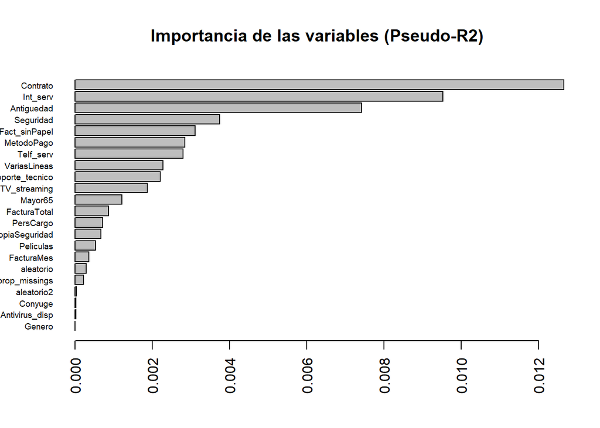

```r
impVariablesLog(modeloInicial,"varObjBin")
```

```r
#si los datos de entrenamiento, no se llaman "data_train", hay que indicarlo
```

En el gráfico se ordenan las aportaciones al pseudoR2 de las distintas variables teniendo Contrato como la gran ganadora ya que aporta muchísimo más que cualquiera.

Ahora, considremos un modelo con las 3 primeras variables, pues presentan incidencias sobre la variable objetivo.

```r
#pruebo uno sencillo con 3 variables
#glm() modelos lineales generalizados
modelo2<-glm(varObjBin~Contrato+Int_serv+Antiguedad,
             data=data_train,family=binomial)
summary(modelo2)
```

```
##
## Call:
## glm(formula = varObjBin ~ Contrato + Int_serv + Antiguedad, family = binomial,
##     data = data_train)
##
## Deviance Residuals:
##     Min       1Q   Median       3Q      Max
## -1.5609  -0.7227  -0.3320   0.8374   3.0953
##
## Coefficients:
##                      Estimate Std. Error z value Pr(>|z|)
## (Intercept)         -0.285833   0.074170  -3.854 0.000116 ***
## ContratoOne year    -0.934753   0.116092  -8.052 8.16e-16 ***
## ContratoTwo year    -1.519162   0.165049  -9.204  < 2e-16 ***
## Int_servFiber optic  1.185144   0.084730  13.987  < 2e-16 ***
## Int_servNo          -0.839774   0.128909  -6.514 7.29e-11 ***
## Antiguedad          -0.031728   0.002123 -14.943  < 2e-16 ***
## ---
## Signif. codes:  0 '***' 0.001 '**' 0.01 '*' 0.05 '.' 0.1 ' ' 1
##
## (Dispersion parameter for binomial family taken to be 1)
##
##     Null deviance: 5882.3  on 5082  degrees of freedom
## Residual deviance: 4450.7  on 5077  degrees of freedom
## AIC: 4462.7
##
## Number of Fisher Scoring iterations: 6
```

```r
pseudoR2(modelo2,data_train,"varObjBin")
```

```
## [1] 0.2433689
```

```r
pseudoR2(modelo2,data_test,"varObjBin")
```

```
## [1] 0.2227703
```

```r
modelo2$rank
```

```
## [1] 6
```

Es un buen modelo, significativo en cuanto a sus parametros , indicando pseudoR2 en test es baja respecto a training lo que quiere decir que puede tener una mayor capacidad predictiva de generalización.

Vamos viendo que pasa con 5 variables y sus interacciones,

```r
#fijandome en la importancia de las variables,
#selecciono aquellas por encima de las aleatorias
modelo3<-glm(varObjBin~Contrato+Int_serv+Antiguedad+Seguridad+Fact_sinPapel,
             data=data_train,family=binomial)
summary(modelo3)
```

```
##
## Call:
## glm(formula = varObjBin ~ Contrato + Int_serv + Antiguedad +
##     Seguridad + Fact_sinPapel, family = binomial, data = data_train)
##
## Deviance Residuals:
##     Min       1Q   Median       3Q      Max
## -1.6370  -0.6788  -0.3236   0.7793   3.0860
##
## Coefficients:
##                      Estimate Std. Error z value Pr(>|z|)
## (Intercept)         -0.428348   0.093509  -4.581 4.63e-06 ***
## ContratoOne year    -0.849902   0.117405  -7.239 4.52e-13 ***
## ContratoTwo year    -1.378671   0.166780  -8.266  < 2e-16 ***
## Int_servFiber optic  1.030385   0.087238  11.811  < 2e-16 ***
## Int_servNo          -0.917338   0.133482  -6.872 6.32e-12 ***
## Antiguedad          -0.030120   0.002165 -13.910  < 2e-16 ***
## SeguridadYes        -0.603508   0.098042  -6.156 7.48e-10 ***
## Fact_sinPapelYes     0.464370   0.084440   5.499 3.81e-08 ***
## ---
## Signif. codes:  0 '***' 0.001 '**' 0.01 '*' 0.05 '.' 0.1 ' ' 1
##
## (Dispersion parameter for binomial family taken to be 1)
##
##     Null deviance: 5882.3  on 5082  degrees of freedom
## Residual deviance: 4376.6  on 5075  degrees of freedom
## AIC: 4392.6
##
## Number of Fisher Scoring iterations: 6
```

```r
pseudoR2(modelo3,data_train,"varObjBin")#es un poquito peor que el anterior,
```

```
## [1] 0.2559651
```

```r
#pero el n. de parametros es casi la mitad
pseudoR2(modelo3,data_test,"varObjBin")
```

```
## [1] 0.2303475
```

```r
modelo3$rank
```

```
## [1] 8
```

El modelo en parámetros aumentó, pero sigue generalizando su capacidad predictiva pseudoR2 para test.

Veamos que pasa con variables continuas, como FacturaTotal, FacturaMes,

```r
#fijandome en la importancia de las variables,
#selecciono aquellas por encima de las aleatorias
modelo4<-glm(varObjBin~Contrato+Int_serv+Antiguedad+Seguridad+Fact_sinPapel+FacturaTotal+FacturaMes,
             data=data_train,family=binomial)
summary(modelo4)
```

```
##
## Call:
## glm(formula = varObjBin ~ Contrato + Int_serv + Antiguedad +
##     Seguridad + Fact_sinPapel + FacturaTotal + FacturaMes, family = binomial,
##     data = data_train)
##
## Deviance Residuals:
##     Min       1Q   Median       3Q      Max
## -1.6985  -0.6756  -0.3255   0.7784   3.0153
##
## Coefficients:
##                       Estimate Std. Error z value Pr(>|z|)
## (Intercept)         -7.884e-01  1.639e-01  -4.811 1.50e-06 ***
## ContratoOne year    -8.358e-01  1.183e-01  -7.062 1.64e-12 ***
## ContratoTwo year    -1.352e+00  1.682e-01  -8.038 9.17e-16 ***
## Int_servFiber optic  8.910e-01  1.181e-01   7.545 4.51e-14 ***
## Int_servNo          -7.844e-01  1.475e-01  -5.318 1.05e-07 ***
## Antiguedad          -2.439e-02  3.869e-03  -6.303 2.91e-10 ***
## SeguridadYes        -6.153e-01  9.972e-02  -6.170 6.83e-10 ***
## Fact_sinPapelYes     4.588e-01  8.462e-02   5.421 5.92e-08 ***
## FacturaTotal        -9.608e-05  4.636e-05  -2.072   0.0382 *
## FacturaMes           6.731e-03  2.663e-03   2.527   0.0115 *
## ---
## Signif. codes:  0 '***' 0.001 '**' 0.01 '*' 0.05 '.' 0.1 ' ' 1
##
## (Dispersion parameter for binomial family taken to be 1)
##
##     Null deviance: 5882.3  on 5082  degrees of freedom
## Residual deviance: 4368.7  on 5073  degrees of freedom
## AIC: 4388.7
##
## Number of Fisher Scoring iterations: 6
```

```r
pseudoR2(modelo4,data_train,"varObjBin")#es un poquito peor que el anterior,
```

```
## [1] 0.2573151
```

```r
#pero el n. de parametros es casi la mitad
pseudoR2(modelo4,data_test,"varObjBin")
```

```
## [1] 0.2363268
```

```r
modelo4$rank
```

```
## [1] 10
```

Vemos que el modelo se mueve bastante en Training, ademas que tuvo ligero aumentos , junto con sus parámetros.La variable Factura Total no aporta tanto al modelo.

```r
#pruebo uno con la interacción de alguna continua como pH y etiqueta
modelo5<-glm(varObjBin~Contrato+Int_serv+Contrato*Antiguedad,
             data=data_train,family=binomial)
summary(modelo5)
```

```
##
## Call:
## glm(formula = varObjBin ~ Contrato + Int_serv + Contrato * Antiguedad,
##     family = binomial, data = data_train)
##
## Deviance Residuals:
##     Min       1Q   Median       3Q      Max
## -1.5801  -0.7176  -0.3311   0.8225   3.1252
##
## Coefficients:
##                              Estimate Std. Error z value Pr(>|z|)
## (Intercept)                 -0.234040   0.077183  -3.032  0.00243 **
## ContratoOne year            -1.575915   0.236984  -6.650 2.93e-11 ***
## ContratoTwo year            -1.380360   0.309828  -4.455 8.38e-06 ***
## Int_servFiber optic          1.178572   0.085051  13.857  < 2e-16 ***
## Int_servNo                  -0.834492   0.129592  -6.439 1.20e-10 ***
## Antiguedad                  -0.034443   0.002489 -13.839  < 2e-16 ***
## ContratoOne year:Antiguedad  0.017880   0.005550   3.222  0.00127 **
## ContratoTwo year:Antiguedad -0.001586   0.006620  -0.240  0.81064
## ---
## Signif. codes:  0 '***' 0.001 '**' 0.01 '*' 0.05 '.' 0.1 ' ' 1
##
## (Dispersion parameter for binomial family taken to be 1)
##
##     Null deviance: 5882.3  on 5082  degrees of freedom
## Residual deviance: 4439.7  on 5075  degrees of freedom
## AIC: 4455.7
##
## Number of Fisher Scoring iterations: 6
```

```r
pseudoR2(modelo5,data_train,"varObjBin")#No parece muy buena idea
```

```
## [1] 0.2452414
```

```r
pseudoR2(modelo5,data_test,"varObjBin")
```

```
## [1] 0.2289342
```

```r
modelo3$rank
```

```
## [1] 8
```

## Evaluación de los modelos por validación cruzada repetida

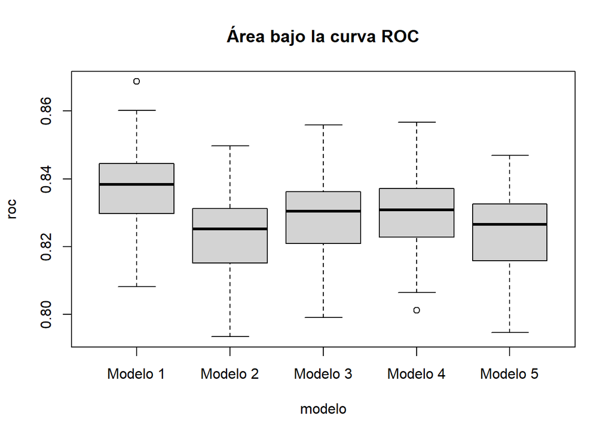

```r
#Validacion cruzada repetida para elegir entre todos

#copia de la variable original
auxVarObj<-todo$varObjBin

#formateo la variable objetivo para que funcione el codigo
todo$varObjBin<-make.names(todo$varObjBin)

total<-c()
modelos<-sapply(list(modeloInicial,modelo2,modelo3,modelo4,modelo5),formula)
for (i in 1:length(modelos)){
  set.seed(1712)
  vcr<-train(as.formula(modelos[[i]]), data = todo,
             method = "glm", family="binomial",metric = "ROC",
             trControl = trainControl(method="repeatedcv", number=5, repeats=20,
                                      summaryFunction=twoClassSummary,
                                      classProbs=TRUE,returnResamp="all")
  )
  total<-rbind(total,data.frame(roc=vcr$resample[,1],modelo=rep(paste("Modelo",i),
                                                                  nrow(vcr$resample))))
}
boxplot(roc~modelo,data=total,main="Área bajo la curva ROC")
```

Podemos decir que todos los modelos son buenos, tiene un ROC en torno a 0.83 y pues la diferencia entre ellos son muy sutiles.

Veamos los valores medios y la desviación respecto a la media de todos los modelos y veamos su comportamiento.

```r
aggregate(roc~modelo, data = total, mean)
```

| modelo | roc |
| --- | --- |
| Modelo 1 | 0.8377258 |
| Modelo 2 | 0.8236357 |
| Modelo 3 | 0.8292555 |
| Modelo 4 | 0.8299413 |
| Modelo 5 | 0.8241096 |

```r
aggregate(roc~modelo, data = total, sd)
```

| modelo | roc |
| --- | --- |
| Modelo 1 | 0.01106853 |
| Modelo 2 | 0.01128318 |
| Modelo 3 | 0.01127070 |
| Modelo 4 | 0.01118737 |
| Modelo 5 | 0.01120894 |

```r
#recupero la variable objetivo en su formato
todo$varObjBin<-auxVarObj

#miro el numero de parametros
modeloInicial$rank
```

```
## [1] 29
```

```r
modelo2$rank
```

```
## [1] 6
```

```r
modelo3$rank
```

```
## [1] 8
```

```r
modelo4$rank
```

```
## [1] 10
```

```r
modelo5$rank
```

```
## [1] 8
```

Podemos decir que, entre ellos las diferencias son muy ligeras y que cualquier modelo podria ayudarnos,para mi, el que mejor incidencia tiene es el modelo 3 o el modelo 5 que tiene el top de las variables que más repercuten.

## Punto de corte óptimo para la probabilidad estimada

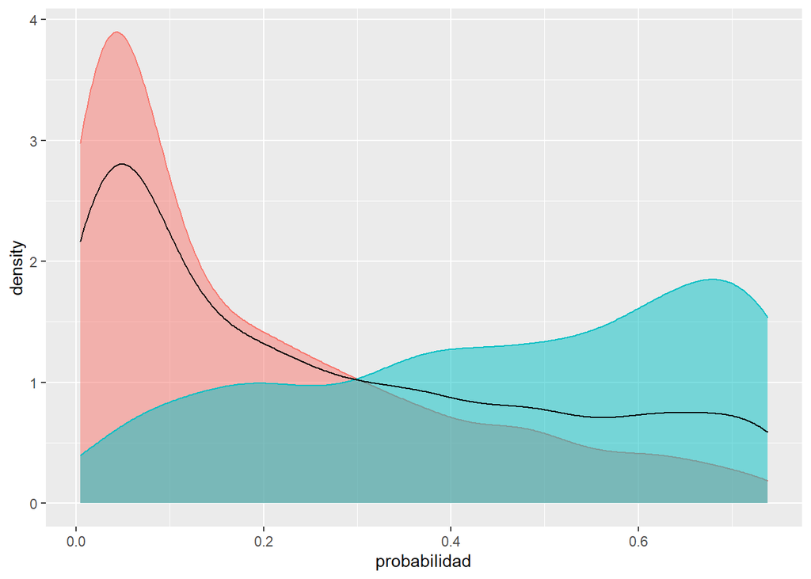

```r
## BUscamos el mejor punto de corte

#gráfico de las probabilidades obtenidas
hist_targetbinaria(predict(modelo3, newdata=data_test,type="response"),data_test$varObjBin,"probabilidad")
```

- Azul: Distribución de probabilidades estimadas para los 1. Está mucho más repartida - Rojo : Distribución de probabilidades estimadas para los 0. Su densidad apunta para valores muy bajos

Note que, el modelo como lo habiamos planteado, tiene dificultades pra reconocer a los 1.

El punto de corte donde la mayor densidad se concentra en la distribición de probabilidades estimadas para cero se aproxima a 0.3.

```r
#probamos dos
sensEspCorte(modelo3,data_test,"varObjBin",0.3,"1")
```

```
##       Accuracy    Sensitivity    Specificity Pos Pred Value Neg Pred Value
##      0.7527559      0.7388724      0.7577706      0.5242105      0.8893082
```

```r
sensEspCorte(modelo3,data_test,"varObjBin",0.57,"1")
```

```
##       Accuracy    Sensitivity    Specificity Pos Pred Value Neg Pred Value
##      0.7929134      0.4005935      0.9346195      0.6887755      0.8119181
```

Coloquemos ahora, una rejilla de puntos de corte posibles entre 0 y 1 y valoremos cual criterio maximiza el accurazy.

```r
## generamos una rejilla de puntos de corte
posiblesCortes<-seq(0,1,0.01)
rejilla<-data.frame(t(rbind(posiblesCortes,sapply(posiblesCortes,function(x)
sensEspCorte(modelo3,data_test,"varObjBin",x,"1")))))
```

[output not shown]

[output cut: 56 more lines]

[output not shown]

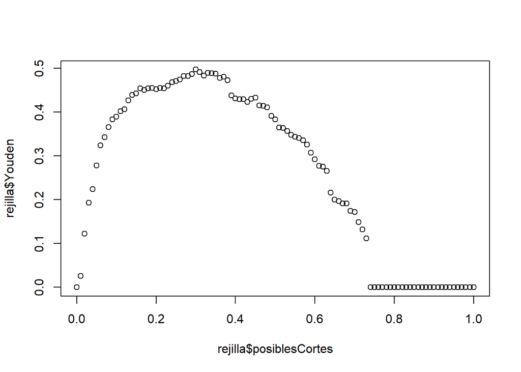

```r
rejilla$Youden<-rejilla$Sensitivity+rejilla$Specificity-1

plot(rejilla$posiblesCortes,rejilla$Youden)
```

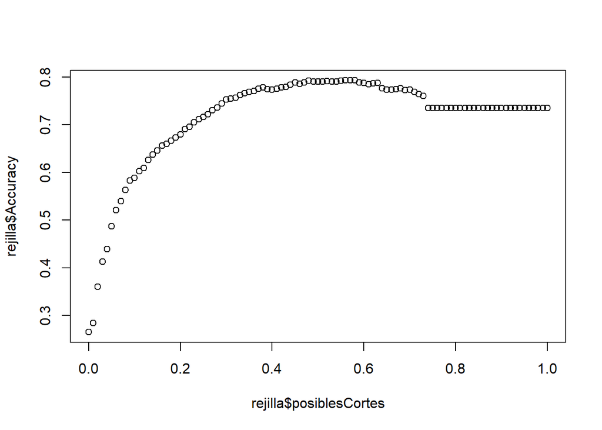

```r
plot(rejilla$posiblesCortes,rejilla$Accuracy)
```

```r
rejilla$posiblesCortes[which.max(rejilla$Youden)]
```

```
## [1] 0.3
```

```r
rejilla$posiblesCortes[which.max(rejilla$Accuracy)]
```

```
## [1] 0.56
```

Veamos ahora los coeficientes del modelo ganador.

```r
# Vemos los coeficientes del modelo ganador
coef(modelo3)
```

```
##         (Intercept)    ContratoOne year    ContratoTwo year Int_servFiber optic
##         -0.42834838         -0.84990164         -1.37867148          1.03038547
##          Int_servNo          Antiguedad        SeguridadYes    Fact_sinPapelYes
##         -0.91733753         -0.03012025         -0.60350793          0.46436997
```

Veamos la matriz de confusión en el conjunto de test,enfrentamos lo que hemos dicho con la verdad verdadera.

```r
# Generar el factos con las clases estimadas en test
pred_test<-factor(ifelse(predict(modelo3,data_test,type = "response")>0.3,1,0))

# Tablas marginales
table(pred_test)
```

```
## pred_test
##   0   1
## 795 475
```

```r
table(data_test$varObjBin)
```

```
##
##   0   1
## 933 337
```

```r
# Matriz de confusión
confusionMatrix(pred_test,data_test$varObjBin, positive = '1')
```

```
## Confusion Matrix and Statistics
##
##           Reference
## Prediction   0   1
##          0 707  88
##          1 226 249
##
##                Accuracy : 0.7528
##                  95% CI : (0.7281, 0.7763)
##     No Information Rate : 0.7346
##     P-Value [Acc > NIR] : 0.07558
##
##                   Kappa : 0.4392
##
##  Mcnemar's Test P-Value : 1.064e-14
##
##             Sensitivity : 0.7389
##             Specificity : 0.7578
##          Pos Pred Value : 0.5242
##          Neg Pred Value : 0.8893
##              Prevalence : 0.2654
##          Detection Rate : 0.1961
##    Detection Prevalence : 0.3740
##       Balanced Accuracy : 0.7483
##
##        'Positive' Class : 1
##
```

## Interpretación de parámetros del modelo logístico

```r
# Ajustamos el modelo a datos completos
modeloC<-glm(formula(modelo3),data=todo,family=binomial)
summary(modeloC)
```

```
##
## Call:
## glm(formula = formula(modelo3), family = binomial, data = todo)
##
## Deviance Residuals:
##     Min       1Q   Median       3Q      Max
## -1.6278  -0.6924  -0.3307   0.7862   3.0947
##
## Coefficients:
##                      Estimate Std. Error z value Pr(>|z|)
## (Intercept)         -0.428380   0.082995  -5.161 2.45e-07 ***
## ContratoOne year    -0.791809   0.103693  -7.636 2.24e-14 ***
## ContratoTwo year    -1.336792   0.146978  -9.095  < 2e-16 ***
## Int_servFiber optic  1.014377   0.077321  13.119  < 2e-16 ***
## Int_servNo          -1.011690   0.122402  -8.265  < 2e-16 ***
## Antiguedad          -0.029742   0.001909 -15.581  < 2e-16 ***
## SeguridadYes        -0.558317   0.086434  -6.459 1.05e-10 ***
## Fact_sinPapelYes     0.459565   0.075023   6.126 9.03e-10 ***
## ---
## Signif. codes:  0 '***' 0.001 '**' 0.01 '*' 0.05 '.' 0.1 ' ' 1
##
## (Dispersion parameter for binomial family taken to be 1)
##
##     Null deviance: 7351.9  on 6352  degrees of freedom
## Residual deviance: 5505.8  on 6345  degrees of freedom
## AIC: 5521.8
##
## Number of Fisher Scoring iterations: 6
```

Para calcular el OR, es decir la probabilidad de evento sobre la probabilidad de no evento, tomemos la siguiente función y aplicando la exponencial por ser la inversa, tenemso que,

```r
# Odds ratios
epiDisplay::logistic.display(modeloC)
```

```
##
## Logistic regression predicting varObjBin : 1 vs 0
##
##                               crude OR(95%CI)   adj. OR(95%CI)
## Contrato: ref.=Month-to-month
##    One year                   0.18 (0.15,0.22)  0.45 (0.37,0.56)
##    Two year                   0.06 (0.05,0.08)  0.26 (0.2,0.35)
##
## Int_serv: ref.=DSL
##    Fiber optic                2.99 (2.63,3.41)  2.76 (2.37,3.21)
##    No                         0.38 (0.3,0.47)   0.36 (0.29,0.46)
##
## Antiguedad (cont. var.)       0.96 (0.96,0.97)  0.97 (0.97,0.97)
##
## Seguridad: Yes vs No          0.36 (0.32,0.42)  0.57 (0.48,0.68)
##
## Fact_sinPapel: Yes vs No      2.5 (2.21,2.83)   1.58 (1.37,1.83)
##
##                               P(Wald's test) P(LR-test)
## Contrato: ref.=Month-to-month                < 0.001
##    One year                   < 0.001
##    Two year                   < 0.001
##
## Int_serv: ref.=DSL                           < 0.001
##    Fiber optic                < 0.001
##    No                         < 0.001
##
## Antiguedad (cont. var.)       < 0.001        < 0.001
##
## Seguridad: Yes vs No          < 0.001        < 0.001
##
## Fact_sinPapel: Yes vs No      < 0.001        < 0.001
##
## Log-likelihood = -2752.92
## No. of observations = 6353
## AIC value = 5521.84
```

Conclusiones del modelo,

-La probabilidad de Fuga respecto a la no Fuga se reduce en un 74% en un Cliente con Contrato por dos años con respecto a la de un cliente con contraro mes a mes.

##Aplicación de modelo a FugaClientes_test

```r
data_test<-readRDS("C:/Users/Laura/Dropbox/UCM/Mineria_y_modelizacion_1/Tarea/FugaClientes_test.RDS")
```

```r
# Generar el factos con las clases estimadas en test
pred_test<-factor(ifelse(predict(modelo3,data_test,type = "response")>0.3,1,0))

# Tablas marginales
table(pred_test)
```

```
## pred_test
##   0   1
## 431 259
```

```r
table(data_test$varObjBin)
```

```
## < table of extent 0 >
```

```r
saveRDS(cbind(data_test[1],pred_test),"FugaPredict_LauraPineros.RDS")
```